# IODS course project

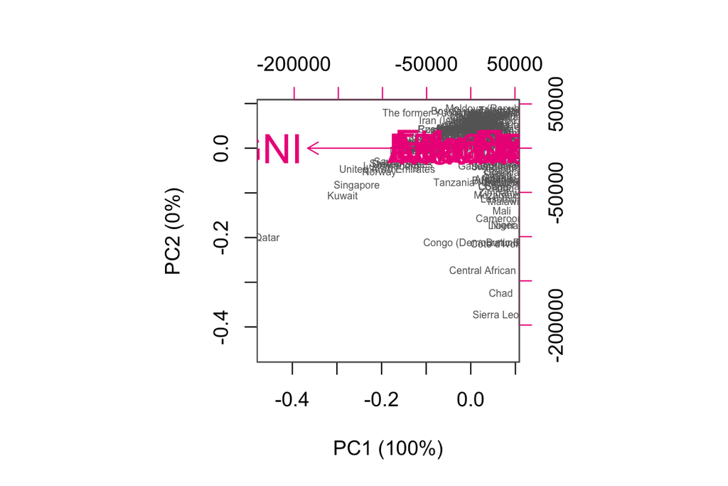

```r
pc_lab <- paste0(names(pca_pr), " (", pca_pr, "%)")
biplot(pca_human, cex = c(0.5, 2), col = c("grey40", "deeppink2"), xlab = pc_lab[1], ylab = pc_lab[2])
```

Part 4: Without standardizing the data, the results of the first analysis are hard to interpret. We see that the arrow of the GNI vector is pointing along the x-axis so GNI is a feature contribuiting to the PC1 dimension. However, because we cannot see the direction the other arrows are point, it is not possible to interpret the relationship between other variables.

After standardizing the results change. We can see that the vectors Labo.FM (percent women in the labor force) and Pari.F (women in parlement) have a very small angle between each other and thus the corrolation between the two is strong. We also can observe that all the other vectors are orthogonal to these two, thus Labo.FM and Pari.F do not have a strong corrolation with the other variables. We also observe that Labo.FM and Pari.F are the only two vector contributing to the PC2 dimension.

We see that there are two vectors pointing to the right, Mat.Mor and AdoBR (Maternal mortality and adolescent birth rate). Again, the small angle between the two vectors demostrange a strong corrolation between the two variables. There are also four vectors pointing to the left. These vectors represent life expectancy at birth, expected education, GNI, and percentage of women with at least a secondary school education. The last two vectors have the smallest angle between them suggesting the strongest corrolation. However, all four variables show strong corrolation. Becuae these four vectors are pointed in the opposite direction from maternal mortality and adolescent birth rate, we observe that there is a strong negative corrolation between these two sets of variables. We also observe that all six are contributing to the PC1 dimension.

```r
human_std <- scale(human)
summary(human_std)
```

```
##     Edu2.FM           Labo.FM           Edu.Exp           Life.Exp
##  Min.   :-2.8189   Min.   :-2.6247   Min.   :-2.7378   Min.   :-2.7188
##  1st Qu.:-0.5233   1st Qu.:-0.5484   1st Qu.:-0.6782   1st Qu.:-0.6425
##  Median : 0.3503   Median : 0.2316   Median : 0.1140   Median : 0.3056
##  Mean   : 0.0000   Mean   : 0.0000   Mean   : 0.0000   Mean   : 0.0000
##  3rd Qu.: 0.5958   3rd Qu.: 0.7350   3rd Qu.: 0.7126   3rd Qu.: 0.6717
##  Max.   : 2.6646   Max.   : 1.6632   Max.   : 2.4730   Max.   : 1.4218
##       GNI             Mat.Mor          Ado.Birth          Parli.F
##  Min.   :-0.9193   Min.   :-0.6992   Min.   :-1.1325   Min.   :-1.8203
##  1st Qu.:-0.7243   1st Qu.:-0.6496   1st Qu.:-0.8394   1st Qu.:-0.7409
##  Median :-0.3013   Median :-0.4726   Median :-0.3298   Median :-0.1403
##  Mean   : 0.0000   Mean   : 0.0000   Mean   : 0.0000   Mean   : 0.0000
##  3rd Qu.: 0.3712   3rd Qu.: 0.1932   3rd Qu.: 0.6030   3rd Qu.: 0.6127
##  Max.   : 5.6890   Max.   : 4.4899   Max.   : 3.8344   Max.   : 3.1850
```

```r
pca_human <- prcomp(human_std)
s <- summary(pca_human)
s
```

```
## Importance of components:
##                           PC1    PC2     PC3     PC4     PC5     PC6
## Standard deviation     2.0708 1.1397 0.87505 0.77886 0.66196 0.53631
## Proportion of Variance 0.5361 0.1624 0.09571 0.07583 0.05477 0.03595
## Cumulative Proportion  0.5361 0.6984 0.79413 0.86996 0.92473 0.96069
##                            PC7     PC8
## Standard deviation     0.45900 0.32224
## Proportion of Variance 0.02634 0.01298
## Cumulative Proportion  0.98702 1.00000
```

```r
pca_pr <- round(100*s$importance[2,], digits = 1)
pca_pr
```

```
##  PC1  PC2  PC3  PC4  PC5  PC6  PC7  PC8
## 53.6 16.2  9.6  7.6  5.5  3.6  2.6  1.3
```

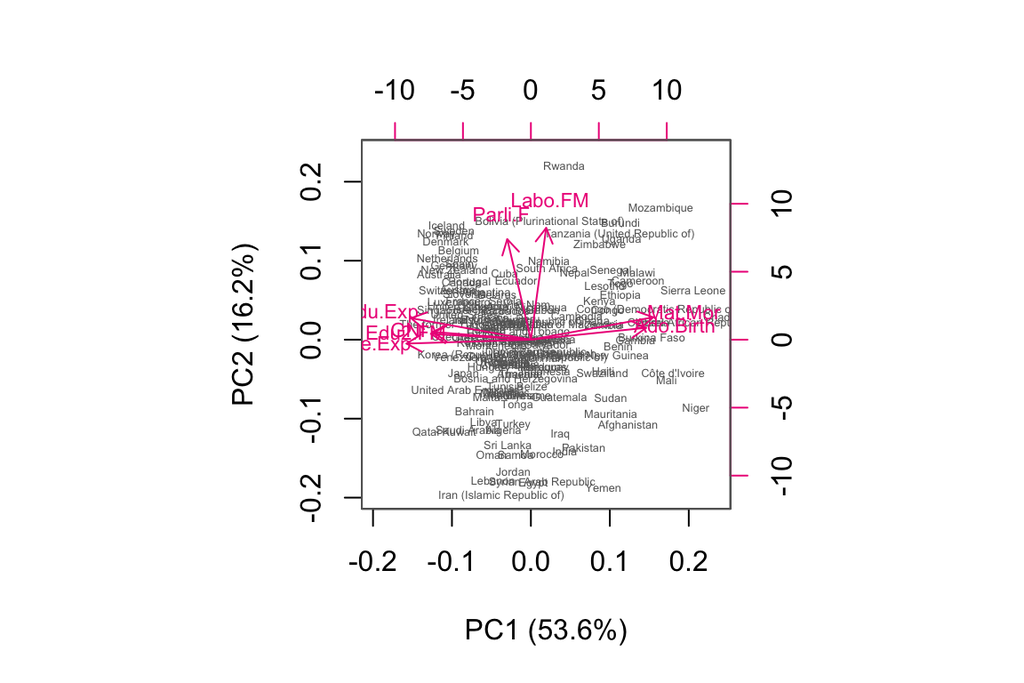

```r
pc_lab <- paste0(names(pca_pr), " (", pca_pr, "%)")
biplot(pca_human, cex = c(0.4, 0.7), col = c("grey40", "deeppink2"), xlab = pc_lab[1], ylab = pc_lab[2])
```

Part 5: I mentioned my interpretations of the first two principal comonent dimensions above but to reiterate, Labo.FM and Pari.F (women in the labor force and women in parliment) are the only two vector contributing to the PC2 dimension, while the vectors pointing to the right, Mat.Mor and AdoBR (maternal mortality and adolescent birth rate), as well as the vectors pointing to the left (life expectancy at birth, expected education, GNI, and percentage of women with at least a secondary school education), are contributing to the PC1 dimension.